# InClassExample

## Project Report - Machine Learning

#### 1. Summarize for us the goal of this project and how machine learning is useful in trying to accomplish it. As part of your answer, give some background on the dataset and how it can be used to answer the project question. Were there any outliers in the data when you got it, and how did you handle those? [relevant rubric items: “data exploration”, “outlier investigation”]

The aim of the project is to build a person of interest identifier on the Enron data set. Enron was a U.S. energy-trading and utilities company that spread one of the biggest accounting frauds in history. Enron's executives employed accounting practices that falsely inflated the company's revenues, which, at the height of the scandal, made the firm become the seventh-largest corporation in the United States. Once the fraud came to light, the company quickly unraveled and filed for bankruptcy on Dec. 2, 2001.

After an investigation by Federal Energy Regulatory Commission, the email archive comprising of 600,000 emails generated by 158 employees and the confidential information collected were made public. For this project we will be using this dataset also known as Enron corpus to figure out if there are patterns within the emails of the people who were persons of interest. In the project with the help of machine learning techniques we will be building an algorithm to identify Enron Employees who may have committed fraud based on the public Enron financial and email dataset.

#### Data Exploration

```python
from sklearn.ensemble import RandomForestClassifier, GradientBoostingClassifier
from sklearn.svm import SVC
from sklearn.linear_model import LogisticRegression
from sklearn.model_selection import GridSearchCV
from sklearn.metrics import f1_score, accuracy_score, auc
from sklearn.model_selection import train_test_split
from sklearn.tree import DecisionTreeClassifier
from sklearn.decomposition import PCA
from sklearn.pipeline import Pipeline
from sklearn.preprocessing import StandardScaler
from sklearn.feature_selection import SelectKBest
from sklearn import svm
from sklearn.neighbors import KNeighborsClassifier
import pandas as pd
import numpy as np
```

```python
import pickle

enron_data = pickle.load(open('D:/Udacity/Machine Learning/ud120-projects/final_project/final_project_dataset_unix.pkl', "rb"))
```

```python
df = pd.DataFrame(enron_data)
df_new = df.transpose().reset_index()
```

```python
df_new.columns
print(df_new.info())
print(df.shape)
print()
print("POI & Non POI information")
poi_non_poi = df_new.poi.value_counts()
poi_non_poi.index=['non-POI', 'POI']
poi_non_poi
```

```
<class 'pandas.core.frame.DataFrame'>
RangeIndex: 146 entries, 0 to 145
Data columns (total 22 columns):
index                        146 non-null object
bonus                        146 non-null object
deferral_payments            146 non-null object
deferred_income              146 non-null object
director_fees                146 non-null object
email_address                146 non-null object
exercised_stock_options      146 non-null object
expenses                     146 non-null object
from_messages                146 non-null object
from_poi_to_this_person      146 non-null object
from_this_person_to_poi      146 non-null object
loan_advances                146 non-null object
long_term_incentive          146 non-null object
other                        146 non-null object
poi                          146 non-null object
restricted_stock             146 non-null object
restricted_stock_deferred    146 non-null object
salary                       146 non-null object
shared_receipt_with_poi      146 non-null object
to_messages                  146 non-null object
total_payments               146 non-null object
total_stock_value            146 non-null object
dtypes: object(22)
memory usage: 25.2+ KB
None
(21, 146)

POI & Non POI information
```

```
non-POI    128
POI         18
Name: poi, dtype: int64
```

From the above code we can see that -

1. we have 22 columns and 146 rows, out of which poi is a binary classification column where 0 represents value for non person of interest and 1 represents value for person of interest. Index corresponds to number and names of the people. The remaining 20 features can be classified as financial features and email features as follows -

   A. Financial Features -

   ```
    1. bonus
    2. deferral_payments
    3. deferred_income
    4. director_fees
    5. exercised_stock_options
    6. expenses
    7. loan_advances
    8. long_term_incentive
    9. other
    10. poi
    11. restricted_stock
    12. restricted_stock_deferred
    13. salary
    14. total_payments
    15. total_Stock_value
   ```

   B. Email Features -

   ```
     1. email_address
     2. from_messaages
     3. from_poi_to_this_person
     4. from_this_person_to_poi
     5. to_messages
   ```

2. Out of 146 records, 128 records are non-POI's and 18 records are POI's.

#### Explore and Handle NaN values

```python
df_new.replace('NaN', np.nan, inplace=True)
```

```python
print(df_new.info())
print("Amount of NaN values in the dataset: ", df_new.isnull().sum().sum())
```

```
<class 'pandas.core.frame.DataFrame'>
RangeIndex: 146 entries, 0 to 145
Data columns (total 22 columns):
index                        146 non-null object
bonus                        82 non-null float64
deferral_payments            39 non-null float64
deferred_income              49 non-null float64
director_fees                17 non-null float64
email_address                111 non-null object
exercised_stock_options      102 non-null float64
expenses                     95 non-null float64
from_messages                86 non-null float64
from_poi_to_this_person      86 non-null float64
from_this_person_to_poi      86 non-null float64
loan_advances                4 non-null float64
long_term_incentive          66 non-null float64
other                        93 non-null float64
poi                          146 non-null bool
restricted_stock             110 non-null float64
restricted_stock_deferred    18 non-null float64
salary                       95 non-null float64
shared_receipt_with_poi      86 non-null float64
to_messages                  86 non-null float64
total_payments               125 non-null float64
total_stock_value            126 non-null float64
dtypes: bool(1), float64(19), object(2)
memory usage: 24.2+ KB
None
Amount of NaN values in the dataset:  1358
```

```python
#df_new.dropna(subset=['bonus'], how='any', inplace=True)
#print(df_new.info())


df_new[['salary','deferral_payments', 'deferred_income','loan_advances', 'bonus','expenses','long_term_incentive','director_fees', 'other', 'total_payments', 'restricted_stock_deferred',
'exercised_stock_options','restricted_stock','total_stock_value']] = df_new[['salary','deferral_payments', 'deferred_income','loan_advances', 'bonus','expenses',
'long_term_incentive','director_fees', 'other', 'total_payments', 'restricted_stock_deferred',
'exercised_stock_options','restricted_stock','total_stock_value']].fillna(value = 0)
```

#### Handling and Removing Outliers

```python
def get_subset_by_IQR(df,column,index):
    q3 = df[column].quantile(0.95)
    iqr = (df[column] > q3)
    for c1, c2 in zip(df[iqr][index], df[iqr][column]):
        print("%-9s %s" % (c1, c2))

print("Outliers by salary: ")
get_subset_by_IQR(df_new,'salary','index')
print()
print("Outliers by bonus: ")
get_subset_by_IQR(df_new,'bonus','index')
```

```
Outliers by salary:
DERRICK JR. JAMES V 492375.0
FASTOW ANDREW S 440698.0
FREVERT MARK A 1060932.0
LAY KENNETH L 1072321.0
PICKERING MARK R 655037.0
SKILLING JEFFREY K 1111258.0
TOTAL     26704229.0
WHALLEY LAWRENCE G 510364.0

Outliers by bonus:
ALLEN PHILLIP K 4175000.0
BELDEN TIMOTHY N 5249999.0
KITCHEN LOUISE 3100000.0
LAVORATO JOHN J 8000000.0
LAY KENNETH L 7000000.0
SKILLING JEFFREY K 5600000.0
TOTAL     97343619.0
```

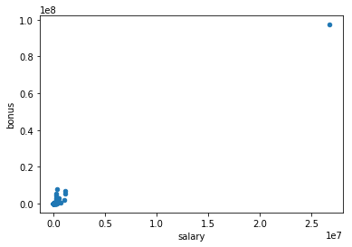

```python
## Drop total
import matplotlib.pyplot as plt
%matplotlib inline
#plt.plot(df_new['bonus'], df_new['salary'], );

from scipy import stats
#df_new[(np.abs(stats.zscore(df_new)) < 3).all(axis=1)]
df_new.plot.scatter(x = 'salary', y = 'bonus')
```

Outliers were investigated based on salary and bonus values. From the above records and the scatter plot we can see that TOTAL has the highest salary and bonus values as it is sum of all the salaries and bonuses. TOTAL is not a record of a POI or non-POI as such and it does not make any sense to keep it in our records. Hence TOTAL is removed from the dataset.

```python
print(df_new['salary'].idxmax())
print(df_new['bonus'].idxmax())
```

```
130
130
```

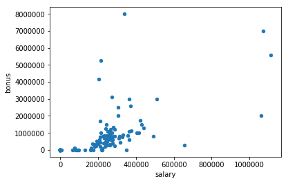

```python
## Since the index of TOTAL is 130, we will drop it
df_new.drop(130, inplace=True)
df_new.plot.scatter(x = 'salary', y = 'bonus')
```

After removing TOTAL from the dataset, we can see that the scatter plot now looks more distributed than the previous ones. The other records were not removed as those records might be POI's and hence removing them does not make sense.

#### 2. What features did you end up using in your POI identifier, and what selection process did you use to pick them? Did you have to do any scaling? Why or why not? As part of the assignment, you should attempt to engineer your own feature that does not come ready-made in the dataset -- explain what feature you tried to make, and the rationale behind it. (You do not necessarily have to use it in the final analysis, only engineer and test it.) In your feature selection step, if you used an algorithm like a decision tree, please also give the feature importances of the features that you use, and if you used an automated feature selection function like SelectKBest, please report the feature scores and reasons for your choice of parameter values. [relevant rubric items: “create new features”, “intelligently select features”, “properly scale features”]

For the initial feature selection, all the features except for email_address, director_fee, index are added in feature list. Since index is just number of each record and name of a person, we will not add that in our list and email address is just text data which will not help in machine learning algorithms. Director_fee were later removed after running all the algorithms as it was found out that SelectKBest gave NaN score for it.

Four new features are added in the dataset- 'fraction_from_poi', 'fraction_to_poi', 'percent_of_stock', 'percent_of_salary' in the dataset.

Feature scaling through standardization was done for all the machine learning algorithms used as it is one of important preprocessing step. Standardization involves rescaling the features such that they have the properties of a standard normal distribution with a mean of zero and a standard deviation of one. The machine learning algorithms which were used such as SVM, K-nearest neighbors etc. require features to be normalized Hence StandardScaler is used to Standardize features by removing the mean and scaling to unit variance.

Feature selection was done using selectKBest method of feature selection to select k features according to the highest scores.

The detailed description of each step is found in the analysis below -

```python
features_list = ['poi','salary', 'deferral_payments', 'total_payments',
'loan_advances', 'bonus', 'restricted_stock_deferred', 'deferred_income',
'total_stock_value', 'expenses', 'exercised_stock_options', 'other',
'long_term_incentive', 'restricted_stock', 'to_messages',
'from_poi_to_this_person', 'from_messages',
'from_this_person_to_poi', 'shared_receipt_with_poi','fraction_from_poi',
'fraction_to_poi', 'percent_of_stock','percent_of_salary']
```

#### Create New Features

```python
#df_new['from_poi_to_this_person']
#df_new['to_messages']
df_new['fraction_from_poi'] = df_new['from_poi_to_this_person']/df_new['to_messages']
df_new['fraction_to_poi'] = df_new['from_this_person_to_poi']/df_new['from_messages']
df_new['percent_of_stock'] = df_new['bonus']/df_new['total_payments']
df_new['percent_of_salary'] = df_new['salary']/df_new['total_payments']
#print(df_new['fraction_to_poi'])
#print(df_new['fraction_from_poi'])
```

After exploring the dataset, I thought adding new financial features and email features might help in improving the accuracies of machine learning algorithms. Hence decided to add two new email features and financial features.

The email features are fraction_from_poi and fraction_to_poi. The features represent the total number of messages to or from a person. The column fraction_from_poi is the fraction of all messages to a person that come from POIs. The column fraction_to_poi is the the fraction of all messages from a person that are sent to POIs. The idea behind adding these two new features is that if a person gets 80% of his/her emails from person of interest, then my intution is that the person might be just another person of interset.

The financial features are percent_of_stock and percent_of_salary. The column percent_of_stock is ratio of bonus to total payments and percent_of_salary is ratio of bonus to total payments and the column percent_of_salary is ratio of salary to tal payments. The idea behind adding these two new features is that if a certain person is a person of interest then he/she might have higher ratio of bonus to total payments and higher ratio of salary to total payments.

```python
df_new.info()
```

```
<class 'pandas.core.frame.DataFrame'>
Int64Index: 145 entries, 0 to 145
Data columns (total 26 columns):
index                        145 non-null object
bonus                        145 non-null float64
deferral_payments            145 non-null float64
deferred_income              145 non-null float64
director_fees                145 non-null float64
email_address                111 non-null object
exercised_stock_options      145 non-null float64
expenses                     145 non-null float64
from_messages                86 non-null float64
from_poi_to_this_person      86 non-null float64
from_this_person_to_poi      86 non-null float64
loan_advances                145 non-null float64
long_term_incentive          145 non-null float64
other                        145 non-null float64
poi                          145 non-null bool
restricted_stock             145 non-null float64
restricted_stock_deferred    145 non-null float64
salary                       145 non-null float64
shared_receipt_with_poi      86 non-null float64
to_messages                  86 non-null float64
total_payments               145 non-null float64
total_stock_value            145 non-null float64
fraction_from_poi            86 non-null float64
fraction_to_poi              86 non-null float64
percent_of_stock             124 non-null float64
percent_of_salary            124 non-null float64
dtypes: bool(1), float64(23), object(2)
memory usage: 29.6+ KB
```

```python
df_new.fillna(value='NaN', inplace = True)

# back into dict
data_dict = df_new.to_dict(orient='index')
my_dataset = data_dict
```

#### Selecting best features

The code below consists of feature_format and test_classifier methods whichc are present in feature_format.py and tester.py given by udacity. The code is added here as the report is created from .ipynb file and it was not possible to call class objects present in .py files in .ipynb files.

```python
import pickle
import sys
from sklearn.cross_validation import StratifiedShuffleSplit
sys.path.append("../tools/")
from feature_format import featureFormat, targetFeatureSplit

PERF_FORMAT_STRING = "\
\tAccuracy: {:>0.{display_precision}f}\tPrecision: {:>0.{display_precision}f}\t\
Recall: {:>0.{display_precision}f}\tF1: {:>0.{display_precision}f}\tF2: {:>0.{display_precision}f}"
RESULTS_FORMAT_STRING = "\tTotal predictions: {:4d}\tTrue positives: {:4d}\tFalse positives: {:4d}\
\tFalse negatives: {:4d}\tTrue negatives: {:4d}"


def test_classifier(clf, dataset, feature_list, folds = 1000):
    data = featureFormat(dataset, feature_list, sort_keys = True)
    labels, features = targetFeatureSplit(data)
    cv = StratifiedShuffleSplit(labels, folds, random_state = 42)
    true_negatives = 0
    false_negatives = 0
    true_positives = 0
    false_positives = 0
    for train_idx, test_idx in cv:
        features_train = []
        features_test  = []
        labels_train   = []
        labels_test    = []
        for ii in train_idx:
            features_train.append( features[ii] )
            labels_train.append( labels[ii] )
        for jj in test_idx:
            features_test.append( features[jj] )
            labels_test.append( labels[jj] )

        ### fit the classifier using training set, and test on test set
        clf.fit(features_train, labels_train)
        predictions = clf.predict(features_test)
        for prediction, truth in zip(predictions, labels_test):
            if prediction == 0 and truth == 0:
                true_negatives += 1
            elif prediction == 0 and truth == 1:
                false_negatives += 1
            elif prediction == 1 and truth == 0:
                false_positives += 1
            elif prediction == 1 and truth == 1:
                true_positives += 1
            else:
                print("Warning: Found a predicted label not == 0 or 1.")
                print("All predictions should take value 0 or 1.")
                print("Evaluating performance for processed predictions:")
                break
    try:
        total_predictions = true_negatives + false_negatives + false_positives + true_positives
        accuracy = 1.0*(true_positives + true_negatives)/total_predictions
        precision = 1.0*true_positives/(true_positives+false_positives)
        recall = 1.0*true_positives/(true_positives+false_negatives)
        f1 = 2.0 * true_positives/(2*true_positives + false_positives+false_negatives)
        f2 = (1+2.0*2.0) * precision*recall/(4*precision + recall)
        print(clf)
        print(PERF_FORMAT_STRING.format(accuracy, precision, recall, f1, f2, display_precision = 5))
        print(RESULTS_FORMAT_STRING.format(total_predictions, true_positives, false_positives, false_negatives, true_negatives))
        print("")
    except:
        print("Got a divide by zero when trying out:", clf)
        print("Precision or recall may be undefined due to a lack of true positive predicitons.")

#!/usr/bin/python

"""
    A general tool for converting data from the
    dictionary format to an (n x k) python list that's
    ready for training an sklearn algorithm

    n--no. of key-value pairs in dictonary
    k--no. of features being extracted

    dictionary keys are names of persons in dataset
    dictionary values are dictionaries, where each
        key-value pair in the dict is the name
        of a feature, and its value for that person

    In addition to converting a dictionary to a numpy
    array, you may want to separate the labels from the
    features--this is what targetFeatureSplit is for

    so, if you want to have the poi label as the target,
    and the features you want to use are the person's
    salary and bonus, here's what you would do:

    feature_list = ["poi", "salary", "bonus"]
    data_array = featureFormat( data_dictionary, feature_list )
    label, features = targetFeatureSplit(data_array)

    the line above (targetFeatureSplit) assumes that the
    label is the _first_ item in feature_list--very important
    that poi is listed first!
"""


import numpy as np

def featureFormat( dictionary, features, remove_NaN=True, remove_all_zeroes=True, remove_any_zeroes=False, sort_keys = False):
    """ convert dictionary to numpy array of features
        remove_NaN = True will convert "NaN" string to 0.0
        remove_all_zeroes = True will omit any data points for which
            all the features you seek are 0.0
        remove_any_zeroes = True will omit any data points for which
            any of the features you seek are 0.0
        sort_keys = True sorts keys by alphabetical order. Setting the value as
            a string opens the corresponding pickle file with a preset key
            order (this is used for Python 3 compatibility, and sort_keys
            should be left as False for the course mini-projects).
        NOTE: first feature is assumed to be 'poi' and is not checked for
            removal for zero or missing values.
    """


    return_list = []

    # Key order - first branch is for Python 3 compatibility on mini-projects,
    # second branch is for compatibility on final project.
    if isinstance(sort_keys, str):
        import pickle
        keys = pickle.load(open(sort_keys, "rb"))
    elif sort_keys:
        keys = sorted(dictionary.keys())
    else:
        keys = dictionary.keys()

    for key in keys:
        tmp_list = []
        for feature in features:
            try:
                dictionary[key][feature]
            except KeyError:
                print("error: key ", feature, " not present")
                return
            value = dictionary[key][feature]
            if value=="NaN" and remove_NaN:
                value = 0
            tmp_list.append( float(value) )

        # Logic for deciding whether or not to add the data point.
        append = True
        # exclude 'poi' class as criteria.
        if features[0] == 'poi':
            test_list = tmp_list[1:]
        else:
            test_list = tmp_list
        ### if all features are zero and you want to remove
        ### data points that are all zero, do that here
        if remove_all_zeroes:
            append = False
            for item in test_list:
                if item != 0 and item != "NaN":
                    append = True
                    break
        ### if any features for a given data point are zero
        ### and you want to remove data points with any zeroes,
        ### handle that here
        if remove_any_zeroes:
            if 0 in test_list or "NaN" in test_list:
                append = False
        ### Append the data point if flagged for addition.
        if append:
            return_list.append( np.array(tmp_list) )

    return np.array(return_list)


def targetFeatureSplit( data ):
    """
        given a numpy array like the one returned from
        featureFormat, separate out the first feature
        and put it into its own list (this should be the
        quantity you want to predict)

        return targets and features as separate lists

        (sklearn can generally handle both lists and numpy arrays as
        input formats when training/predicting)
    """

    target = []
    features = []
    for item in data:
        target.append( item[0] )
        features.append( item[1:] )

    return target, features
```

Next, features and labels from dataset are extracted for local testing.

```python
data = featureFormat(my_dataset, features_list, sort_keys = True)
labels, features = targetFeatureSplit(data)
```

Next, to get idea of which classifiers can be used, different classifiers are tried. cross_val_score is used to calculate cross validate score of each model. Given an estimator, the cross-validation object and the input dataset, the cross_val_score splits the data repeatedly into a training and a testing set, trains the estimator using the training set and computes the scores based on the testing set for each iteration of cross-validation. First the data is standardized using StandardScaler method to help standardize the dataset’s features onto unit scale (mean = 0 and variance = 1).

```python
transformed_features = StandardScaler().fit_transform(features)
```

Once the data is standardized, PCA is used to generate principal components from possibly correlated values. PCA is effected by scale so we scaled the features in the data before applying PCA.

```python
pca = PCA()
#pca.fit(features)
#fileobj = open(features.csv, mode='wb')
pca_features = pca.fit_transform(transformed_features)
#pca_features.tofile("test.csv"," ")
#print(pca.explained_variance_ratio_)
#print(pca_features.shape)
```

Once we get the new components using PCA, feature selection is done on different values of k such as k = 12, 14, 15, 16, 17, 18, 20 and the selected features are used on different models calcuate cross validate scores. For feature select, SelectKbest algorithm is used. Below is the output and code of the scores for k = 18

```python
import pandas as pd
from sklearn.feature_selection import SelectKBest, f_classif, chi2

#ch2 = SelectKBest(chi2, k=2)
selector = SelectKBest(k = 18)
selected_features = selector.fit_transform(pca_features, labels)
#print(X_new)
#print(selected_features.shape)
#print(selector.pvalues_)
```

```python
from sklearn.naive_bayes import GaussianNB
from sklearn.model_selection import cross_val_score

rf_mod = RandomForestClassifier(n_estimators=100)
log_mod = LogisticRegression()
svm_mod = SVC()
clf_mod = DecisionTreeClassifier()
gnb_mod = GaussianNB()
knb_mod = KNeighborsClassifier()

print("The cross validation score for Random Forest : ")
print(cross_val_score(rf_mod, selected_features,labels))
print("The mean score for Random forest is :", cross_val_score(rf_mod, selected_features,labels).mean())
print()
print("The cross validation score for Logistic Regression : ")
print(cross_val_score(log_mod, selected_features,labels))
print("The mean score for Logistic Regression is :", cross_val_score(log_mod, selected_features,labels).mean())
print()
print("The cross validation score for Support Vector machine : ")
print(cross_val_score(svm_mod, selected_features,labels))
print("The mean score for Support Vector machine is :", cross_val_score(svm_mod, selected_features,labels).mean())
print(cross_val_score(clf_mod, selected_features,labels))
print()
print("The cross validation score for Decision Tree : ")
print("The mean score for Decision Tree is :", cross_val_score(clf_mod, selected_features,labels).mean())
print(cross_val_score(gnb_mod, selected_features,labels))
print()
print("The cross validation score for Gaussian Naive Bayes : ")
print("The mean score for Gaussian Naive Bayes is :", cross_val_score(gnb_mod, selected_features,labels).mean())
print()
print("The cross validation score for knn : ")
print(cross_val_score(knb_mod, selected_features,labels))
print("The mean score for knn is :", cross_val_score(knb_mod, selected_features,labels).mean())

#print("The accuracy for random forest is {}".format(accuracy_score(Y_test, rf_preds)))
#print("The accuracy for logistic regression is {}".format(accuracy_score(Y_test, log_preds)))
#print("The accuracy for svm is {}".format(accuracy_score(Y_test, svm_preds)))
```

```
The cross validation score for Random Forest :
[ 0.875       0.875       0.89583333]
The mean score for Random forest is : 0.881944444444

The cross validation score for Logistic Regression :
[ 0.77083333  0.85416667  0.9375    ]
The mean score for Logistic Regression is : 0.854166666667

The cross validation score for Support Vector machine :
[ 0.875  0.875  0.875]
The mean score for Support Vector machine is : 0.875
[ 0.77083333  0.85416667  0.85416667]

The cross validation score for Decision Tree :
The mean score for Decision Tree is : 0.819444444444
[ 0.8125      0.79166667  0.72916667]

The cross validation score for Gaussian Naive Bayes :
The mean score for Gaussian Naive Bayes is : 0.777777777778

The cross validation score for knn :
[ 0.85416667  0.875       0.875     ]
The mean score for knn is : 0.868055555556
```

#### Parameter Tuning

Data is splitted using train_test_split as follows -

```python
from sklearn.cross_validation import train_test_split
features_train, features_test, labels_train, labels_test = train_test_split(features, labels, test_size=0.3, random_state=42)
```

The task here is to tune the classifiers selected above to achieve better than .3 precision and recall using the tester script. Using GridSearch, each set of model (by each set here we mean - models which differ from each other in their parameter values, which lie on a grid) each model is trained and evaluted. GridSearchCV exhaustively considers all parameter combinations.

The parameters of the estimator used to apply these methods are optimized by cross-validated grid-search over a parameter grid.

To evaluate the predcitions on the testing set, F-beta score is used as scoring parameter in GridSearchCV. The F-beta score is the weighted harmonic mean of precision and recall, reaching its optimal value at 1 and its worst value at 0.

Pipeline is also used to sequentially apply a list of transforms in the order of feature scaling, PCA (not in all models) followed by feature selection and a final estimator.

First we start with Support Vector Machines.

```python
from sklearn.metrics import fbeta_score, make_scorer
ftwo_scorer = make_scorer(fbeta_score, beta=2)
```

```python
from sklearn import svm
from sklearn.feature_selection import f_regression
from sklearn.metrics import precision_score
from sklearn.metrics import recall_score
from sklearn.metrics import f1_score


import warnings
warnings.filterwarnings("ignore")
svm = Pipeline([('scaler',StandardScaler()),('kbest',SelectKBest(f_regression)), ('svm',svm.SVC())])

param_grid = ([{'svm__C': np.logspace(-2, 3, 5),
                'svm__gamma': [0.5],
                'svm__degree':[1,2],
                'svm__kernel': ['rbf','poly'],
                'svm__random_state':[np.random.RandomState(0)],
                'kbest__k':[14,15,16,17,18,20]}])

grid = GridSearchCV(svm, param_grid, scoring=ftwo_scorer)
svm_clf = grid.fit(features_train, labels_train).best_estimator_


pred = svm_clf.predict(features_test)
accuracy = accuracy_score(labels_test, pred)
precisionScore = precision_score(labels_test, pred)
recallScore =  recall_score(labels_test, pred)
F1 = 2 * (precisionScore * recallScore) / (precisionScore + recallScore)

#print('accuracy for support vector machine is ',accuracy)
#print ('precision for support vector machine is', precisionScore)
#print ('recall for support vector machine is', recallScore)
#print ('f1 score for support vector machine is', F1)

print()
print("The metrics for the test_Classifier are as follows - ")
test_classifier(svm_clf, my_dataset, features_list)
```

```
The metrics for the test_Classifier are as follows -
Pipeline(memory=None,
     steps=[('scaler', StandardScaler(copy=True, with_mean=True, with_std=True)), ('kbest', SelectKBest(k=15, score_func=<function f_regression at 0x000001ACC4A9AF28>)), ('svm', SVC(C=56.234132519034908, cache_size=200, class_weight=None, coef0=0.0,
  decision_function_shape='ovr', degree=2, gamma=0.5, kernel='poly',
  max_iter=-1, probability=False,
  random_state=<mtrand.RandomState object at 0x000001ACC796C8B8>,
  shrinking=True, tol=0.001, verbose=False))])
	Accuracy: 0.79653	Precision: 0.24012	Recall: 0.24300	F1: 0.24155	F2: 0.24242
	Total predictions: 15000	True positives:  486	False positives: 1538	False negatives: 1514	True negatives: 11462
```

The parameters used in SVM model are - C, gamma, degree, kernel and random_state. We do feature selection on multiple k values ranging from k = 14 to 20.

We can see that the optimal model has values - C = 56.234132519034908, gamma = 0.5, degree = 2, kernel = 'poly' and k = 15.

Next we see what 15 features were selected by SelectKBest.

```python
from collections import OrderedDict
from operator import itemgetter

feature_list = features_list[1:]

best_features = {}

for i in range(15):
    best_features[feature_list[i]] = svm_clf.get_params()['kbest'].scores_[i]

d = OrderedDict(sorted(best_features.items(), key=itemgetter(1), reverse=True))

print(d)
```

[output not shown]

From this list we can see that any of the new features added are not part of the optimal model. Next we look at Gaussian Naive Bayes Classifier.

```python
## Gaussian Naive Bayes
from sklearn.naive_bayes import GaussianNB
import warnings
warnings.filterwarnings("ignore")

gnb = GaussianNB()
gnb = Pipeline([('scaler',StandardScaler()),('pca',PCA()), ('gnb',GaussianNB())])

param_grid = ([{'pca__n_components':[14,15,16]}])

grid = GridSearchCV(gnb, param_grid, scoring=ftwo_scorer)
gnb_clf = grid.fit(features_train, labels_train).best_estimator_


pred = gnb_clf.predict(features_test)
accuracy = accuracy_score(labels_test, pred)
precisionScore = precision_score(labels_test, pred)
recallScore =  recall_score(labels_test, pred)
F1 = 2 * (precisionScore * recallScore) / (precisionScore + recallScore)

#print('accuracy for Gaussian Naive Bayes is ',accuracy)
#print ('precision for Gaussian Naive Bayes is', precisionScore)
#print ('recall for Gaussian Naive Bayes is', recallScore)
#print ('f1 score for Gaussian Naive Bayes is', F1)

print()
print("The metrics for the test_Classifier are as follows - ")
test_classifier(gnb_clf, my_dataset, features_list)
```

```
The metrics for the test_Classifier are as follows -
Pipeline(memory=None,
     steps=[('scaler', StandardScaler(copy=True, with_mean=True, with_std=True)), ('pca', PCA(copy=True, iterated_power='auto', n_components=14, random_state=None,
  svd_solver='auto', tol=0.0, whiten=False)), ('gnb', GaussianNB(priors=None))])
	Accuracy: 0.80280	Precision: 0.30639	Recall: 0.37900	F1: 0.33885	F2: 0.36185
	Total predictions: 15000	True positives:  758	False positives: 1716	False negatives: 1242	True negatives: 11284
```

The parameters tuned here are just n_component values for pca. The model runs for n_components = 14,15,16. The best n_components selected are 14

Next we look at k-nearest neighbors.

```python
##k-nn
from sklearn.neighbors import KNeighborsClassifier

knn = Pipeline([('scaler',StandardScaler()),('kbest',SelectKBest()), ('knn', KNeighborsClassifier())])

param_grid = ([{'knn__n_neighbors':[1,3,5,7,9,11],
                'kbest__k':[14,16,18,20]}])

grid = GridSearchCV(knn, param_grid, scoring=ftwo_scorer)
knn_clf = grid.fit(features_train, labels_train).best_estimator_


pred = knn_clf.predict(features_test)
accuracy = accuracy_score(labels_test, pred)
precisionScore = precision_score(labels_test, pred)
recallScore =  recall_score(labels_test, pred)
F1 = 2 * (precisionScore * recallScore) / (precisionScore + recallScore)

#print('accuracy for k-nn Classifier is ',accuracy)
#print ('precision for k-nn Classifier is', precisionScore)
#print ('recall for k-nn Classifier is', recallScore)
#print ('f1 score for k-nn Classifier is', F1)

print()
print("The metrics for the test_Classifier are as follows - ")
test_classifier(knn_clf, my_dataset, features_list)
```

```
The metrics for the test_Classifier are as follows -
Pipeline(memory=None,
     steps=[('scaler', StandardScaler(copy=True, with_mean=True, with_std=True)), ('kbest', SelectKBest(k=20, score_func=<function f_classif at 0x000001ACC4A9AD90>)), ('knn', KNeighborsClassifier(algorithm='auto', leaf_size=30, metric='minkowski',
           metric_params=None, n_jobs=1, n_neighbors=5, p=2,
           weights='uniform'))])
	Accuracy: 0.85100	Precision: 0.11726	Recall: 0.01800	F1: 0.03121	F2: 0.02167
	Total predictions: 15000	True positives:   36	False positives:  271	False negatives: 1964	True negatives: 12729
```

From the results, we can see that the Accuracy: 0.85100 Precision: 0.11726 Recall: 0.01800 F1: 0.03121.

Here the parameters tuned were k value for SelectKBest and n_neighbors for k-nn.

```python
from collections import OrderedDict
from operator import itemgetter

feature_list = features_list[1:]

best_features = {}

for i in range(14):
    best_features[feature_list[i]] = knn_clf.get_params()['kbest'].scores_[i]

d = OrderedDict(sorted(best_features.items(), key=itemgetter(1), reverse=True))

print(d)
```

[output not shown]

```python
## Decision Tree
from sklearn.tree import DecisionTreeClassifier
from scipy.stats import randint

dtc = Pipeline([('scaler',StandardScaler()),('kbest',SelectKBest()), ('dtc', DecisionTreeClassifier())])

param_grid = ([{'dtc__class_weight': [None],
                'dtc__criterion': ['gini', 'entropy'],
                'dtc__min_samples_split': [2, 5, 10, 15, 20],
                'dtc__max_depth': [None, 2, 5, 10],
                'dtc__min_samples_leaf': [1, 5, 10],
                'dtc__random_state':[42],
                'kbest__k':[14,15,16,17,18,20]}])

grid = GridSearchCV(dtc, param_grid, scoring=ftwo_scorer)
dtc_clf = grid.fit(features_train, labels_train).best_estimator_


pred = dtc_clf.predict(features_test)
accuracy = accuracy_score(labels_test, pred)
precisionScore = precision_score(labels_test, pred)
recallScore =  recall_score(labels_test, pred)
F1 = 2 * (precisionScore * recallScore) / (precisionScore + recallScore)

#print('accuracy for Decision Tree Classifier is ',accuracy)
#print ('precision for Decision Tree Classifier is', precisionScore)
#print ('recall for Decision Tree Classifier is', recallScore)
#print ('f1 score for Decision Tree Classifier is', F1)

print()
print("The metrics for the test_Classifier are as follows - ")
test_classifier(dtc_clf, my_dataset, features_list)
```

```
The metrics for the test_Classifier are as follows -
Pipeline(memory=None,
     steps=[('scaler', StandardScaler(copy=True, with_mean=True, with_std=True)), ('kbest', SelectKBest(k=16, score_func=<function f_classif at 0x000001ACC4A9AD90>)), ('dtc', DecisionTreeClassifier(class_weight=None, criterion='entropy', max_depth=None,
            max_features=None, max_leaf_nodes=None,...        min_weight_fraction_leaf=0.0, presort=False, random_state=42,
            splitter='best'))])
	Accuracy: 0.84873	Precision: 0.41951	Recall: 0.35050	F1: 0.38191	F2: 0.36242
	Total predictions: 15000	True positives:  701	False positives:  970	False negatives: 1299	True negatives: 12030
```

The parameters used in Decision tree classifier model are - class_weight, criterion, min_samples_split, max_depth and min_samples_leaf. We do feature selection on multiple k values ranging from k = 14 to 20.

We can see that the optimal model has values - criterion='entropy', max_depth=None, max_features=None, max_leaf_nodes=None, min_weight_fraction_leaf=0.0 and k = 16.

Next we see what 16 features were selected by SelectKBest.

```python
from collections import OrderedDict
from operator import itemgetter

feature_list = features_list[1:]

best_features = {}

for i in range(16):
    best_features[feature_list[i]] = knn_clf.get_params()['kbest'].scores_[i]

d = OrderedDict(sorted(best_features.items(), key=itemgetter(1), reverse=True))

print(d)
```

[output not shown]

#### Compare performance of a model based on new and existing features

```python
from sklearn.tree import DecisionTreeClassifier
from scipy.stats import randint

features_list_old = ['poi','salary', 'deferral_payments', 'total_payments',
'loan_advances', 'bonus', 'restricted_stock_deferred', 'deferred_income',
'total_stock_value', 'expenses', 'exercised_stock_options', 'other',
'long_term_incentive', 'restricted_stock', 'to_messages',
'from_poi_to_this_person', 'from_messages',
'from_this_person_to_poi', 'shared_receipt_with_poi']

#data_old = featureFormat(my_dataset, features_list_old, sort_keys = True)
#labels_old, features_old = targetFeatureSplit(data_old)

#from sklearn.cross_validation import train_test_split
#features_train_old, features_test_old, labels_train_old, labels_test_old = train_test_split(features_old, labels_old, test_size=0.3, random_state=42)

dtc_old = Pipeline([('scaler',StandardScaler()),('kbest',SelectKBest()), ('dtc_old', DecisionTreeClassifier())])

param_grid = ([{'dtc_old__class_weight': [None],
                'dtc_old__criterion': ['gini', 'entropy'],
                'dtc_old__min_samples_split': [2, 5, 10, 15, 20],
                'dtc_old__max_depth': [None, 2, 5, 10],
                'dtc_old__min_samples_leaf': [1, 5, 10],
                'dtc_old__random_state':[42],
                'kbest__k':[14,15,16,17,18]}])

grid = GridSearchCV(dtc_old, param_grid, scoring=ftwo_scorer)
dtc_old_clf = grid.fit(features_train, labels_train).best_estimator_

#print('accuracy for Decision Tree Classifier is ',accuracy)
#print ('precision for Decision Tree Classifier is', precisionScore)
#print ('recall for Decision Tree Classifier is', recallScore)
#print ('f1 score for Decision Tree Classifier is', F1)

print()
print("The metrics for the test_Classifier without new features are as follows -")
test_classifier(dtc_old_clf, my_dataset, features_list_old)
```

[output not shown]

We can see that without the new features the precision and recall are not above 0.3. They are lower than the model which has new features. So we can see that even though the optimized model does not have the new features in k best features, they are certainly helping improve precision and recall score. Now we look at the best model.

```python
#### Best matrix
## Decision Tree
from sklearn.tree import DecisionTreeClassifier
from scipy.stats import randint

dtc = Pipeline([('scaler',StandardScaler()),('kbest',SelectKBest()), ('dtc', DecisionTreeClassifier())])

param_grid = ([{'dtc__class_weight': [None],
                'dtc__criterion': ['gini', 'entropy'],
                'dtc__min_samples_split': [2, 5, 10, 15, 20],
                'dtc__max_depth': [None, 2, 5, 10],
                'dtc__min_samples_leaf': [1, 5, 10],
                'kbest__k':[14,15,16,17,18,20]}])

grid = GridSearchCV(dtc, param_grid, scoring=ftwo_scorer)
clf = grid.fit(features_train, labels_train).best_estimator_


pred = dtc_clf.predict(features_test)
accuracy = accuracy_score(labels_test, pred)
precisionScore = precision_score(labels_test, pred)
recallScore =  recall_score(labels_test, pred)
F1 = 2 * (precisionScore * recallScore) / (precisionScore + recallScore)
```

#### 4. What does it mean to tune the parameters of an algorithm, and what can happen if you don’t do this well? How did you tune the parameters of your particular algorithm? What parameters did you tune? [relevant rubric items: “discuss parameter tuning”, “tune the algorithm”]

Better results from algorithms can be achieved by exploring and fine tuning the configuration for those algorithms. Machine learning algorithms are parameterized and modification of those parameters can influence the outcome of the learning process. A small subset of the parameters can have a large impact on the predictive or computation performance of the model. To tune the parameters of an algorithm means to change the parameters or hyper parameters of an algorithm, test the results of an algorithm and then update the values of the parameters if required. These steps are repeated until we get better results.

Following parameters were tuned for each algorithm -

1. Support Vector Machines - C, gamma, degree, kernel and random_state.
2. k-nearest neighbors - n_neighbors
3. Decision Tree - class_weight, criterion, min_samples_split, max_depth and min_samples_leaf

The parameters were tuned by trial and repeat method. For each change in the parameter, performance was evaluated for each model and depending on which model gave optimum results, the parameters were selected.

#### 5. What is validation, and what’s a classic mistake you can make if you do it wrong? How did you validate your analysis? [relevant rubric items: “discuss validation”, “validation strategy”]

Validation is a model validation technique for assessing how the results of a statistical analysis will generalize to an independent data set. The validation set approach involves randomly dividing the available set of observations into two parts, a training set and a validation set. The resulting validation set error rate—typically assessed using MSE in the case of a quantitative response—provides an estimate of the test error rate. The goal of cross validation is to define a dataset to "test" the model in the training phase (i.e., the validation set), in order to limit problems like overfitting. If the data is not splitted into testing and training set, the model suffers from problem of overfitting.

In k-fold cross validation, there is a bias-variance tradeoff associated with the choice of k in k-fold cross validation. So if k is not selected properly, we can observe excessively high bias or high variance.

test_classifier method which is used to test the performance of the classifier uses StratifiedShuffleSplit. StratifiedShuffleSplit ensures that relative class frequencies is approximately preserved in each train and validation fold. This is important for our dataset as we have small dataset and the number of POI's in the dataset are also low.

### References –

1. http://scikit-learn.org
2. Enron https://www.investopedia.com/terms/e/enron.asp#ixzz5Axb7BEul
3. https://www.cs.cmu.edu/~enron/
4. Stackoverflow.com
5. https://towardsdatascience.com/pca-using-python-scikit-learn-e653f8989e60